# Neural Activity and Behavioral Predictions: An Analysis of Behavioral Outcomes in Mice

Kyle Guanzon

2024-03-17

# Abstract

Neural activity and behavioral outcomes are examines to illustrate the complexities of decision-making in mammal species. This study leverages the comprehensive neural spike train data from the groundbreaking research by Steinmetz et al. (2019), focusing on the visual cortex’s response to stimuli in mice. This report bridges the gap between observed neural activity and the predictive modeling of behavioral outcomes. Undergoing thorough exploratory data analysis methods, key patterns and relationships within spike trains are identified, in relation to the success and failure of behavioral responses to visual stimuli. Machine learning algorithms such as XGBoost is implemented to train the model created, which is further evaluated by AUROC. Resources and code were obtained from STA 141A discussions and course notes, as well as ChatGPT.

# Section 1: Introduction

In the study conducted by Steinmetz et al. (2019), experiments were performed on a total of 10 mice over 39 sessions. Each session comprised several hundred trials, during which visual stimuli were randomly presented to the mouse on two screens positioned on both sides of it. The stimuli varied in terms of contrast levels, which took values in {0, 0.25, 0.5, 1}, with 0 indicating the absence of a stimulus. The mice were required to make decisions based on the visual stimuli, using a wheel controlled by their forepaws. A reward or penalty (i.e., feedback) was subsequently administered based on the outcome of their decisions. In particular,

- When left contrast > right contrast, success (1) if turning the wheel to the right and failure (-1) otherwise.
- When right contrast > left contrast, success (1) if turning the wheel to the left and failure (-1) otherwise.
- When both left and right contrasts are zero, success (1) if holding the wheel still and failure (-1) otherwise.
- When left and right contrasts are equal but non-zero, left or right will be randomly chosen (50%) as the correct choice.

The activity of the neurons in the mice’s visual cortex was recorded during the trials and made available in the form of spike trains, which are collections of timestamps corresponding to neuron firing. In this project, we focus specifically on the spike trains of neurons from the onset of the stimuli to 0.4 seconds post-onset. In addition, we only use 18 sessions (Sessions 1 to 18) from four mice: Cori, Frossman, Hence, and Lederberg.

This study aims to identify patterns and relationships that can help us understand the neural basis of decision-making by concentrating on the finely tuned spike trains of neurons in the mice’s visual cortex and the circumstances of the visual stimuli presented. This project aims to improve our predictive capabilities by combining exploratory data analysis data integration strategies and predictive modeling. The insights it provides could have a wide range of implications for neuroscience especially in terms of comprehending cognitive processes and creating artificial intelligence systems inspired by neurons.

This project not only advances our understanding of neural activity patterns linked to decision-making which benefits the field of computational neuroscience but it also shows how machine learning techniques can be used to decipher the intricate workings of the human brain. We are at the cusp of making new discoveries in the analysis and modeling of neural and behavioral data that may shed more light on the neural circuitry underlying decision-making in mammals.

## Data Structure

A total of 18 RDS files are provided that contain the records from 18 sessions. The name of mouse from `mouse_name` and date of the experiment from `date_exp` in each RDS file.

There are a total of 18 RDS files provided that contain the records from 18 sessions. Each file contains the name of mouse from `mouse_name` and date of the experiment from `date_exp`.

We then create a consolidated data frame that includes session number, mouse name, and date of experiment for each session, as a RDS file overview:

```
##    session_number mouse_name   date_exp trial_count
## 1               1       Cori 2016-12-14         114
## 2               2       Cori 2016-12-17         251
## 3               3       Cori 2016-12-18         228
## 4               4  Forssmann 2017-11-01         249
## 5               5  Forssmann 2017-11-02         254
## 6               6  Forssmann 2017-11-04         290
## 7               7  Forssmann 2017-11-05         252
## 8               8      Hench 2017-06-15         250
## 9               9      Hench 2017-06-16         372
## 10             10      Hench 2017-06-17         447
## 11             11      Hench 2017-06-18         342
## 12             12  Lederberg 2017-12-05         340
## 13             13  Lederberg 2017-12-06         300
## 14             14  Lederberg 2017-12-07         268
## 15             15  Lederberg 2017-12-08         404
## 16             16  Lederberg 2017-12-09         280
## 17             17  Lederberg 2017-12-10         224
## 18             18  Lederberg 2017-12-11         216
```

We then, now, explore what’s in a session by randomly exploring a session from Session 1-18, before we explore the rest of the 18 sessions.

Its a wise strategic move to begin the EDA with a single session before working your way through the entire dataset. This will help better understand the data hone your analysis methods guarantee computational efficiency and create a baseline for additional comparative analyses. By using this method the data analysis becomes more high-quality and the overall understanding of the data becomes more comprehensive and logical.

### What’s in a Session’s Trial?

We randomly choose Session 12 to understand the data structure.

```
##                Length Class  Mode
## contrast_left  340    -none- numeric
## contrast_right 340    -none- numeric
## feedback_type  340    -none- numeric
## mouse_name       1    -none- character
## brain_area     698    -none- character
## date_exp         1    -none- character
## spks           340    -none- list
## time           340    -none- list
```

- `feedback_type`: type of the feedback, 1 for success and -1 for failure
- `contrast_left`: contrast of the left stimulus
- `contrast_right`: contrast of the right stimulus
- `time`: centers of the time bins for `spks`
- `spks`: numbers of spikes of neurons in the visual cortex in time bins defined in `time`
- `brain_area`: area of the brain where each neuron lives

### Neural Data

We browse through Neural Data by exploring the variables brain_area and spks of Session 12.

```
##    Length     Class      Mode
##       698 character character
```

There are a total of 698 neurons in Session 12. Each entry corresponds to a neuron, indicating the brain area where that neuron is located. We also obtain the total number of trials from the `length()` of spks, which is 340.

The distribution of neurons with their corresponding brain areas is illustrated below:

```
##
##   ACA   CA1    DG   LGd    LH    MD   MOs    PL  root   SUB VISam  VISp
##    16    50    65    11    18   126     6    56   100   105    79    66
```

This means that of all 340 trials in Session 12, the 698 neurons are distributed with their corresponding brain areas.

### Behavioral Data

We browse through Behavioral Data by exploring the variables `contrast_left`, `contrast_right`, and `feedback_type` of Session 12.

The stimuli varied in terms of contrast levels, which took values in {0, 0.25, 0.5, 1}, with 0 indicating the absence of a stimulus.

Taking the summary statistics of `contrast_left` of Session 12, we can see that the average stimulus provided to the mouse is 0.2889706, the highest stimulus is 1, whereas the lowest stimulus value given is 0.

The distribution of the four stimulus levels in left contrast is provided below, which sums up to the total number of trials in `contrast_left` for Session 12, which is 340.

```
##
##    0 0.25  0.5    1
##  173   55   55   57
```

We also explore similarly for `contrast_right`:

Taking the summary statistics of contrast_right of Session 12, we can see that the average stimulus provided to the mouse is 0.325, the highest stimulus is 1, whereas the lowest stimulus value given is 0.

```r
table(session[[12]]$contrast_right)
```

```
##
##    0 0.25  0.5    1
##  167   50   50   73
```

Taking the summary statistics of `feedback_type` of Session 12, we can see that the average stimulus provided to the mouse is 0.4764706, the highest stimulus is 1, whereas the lowest stimulus value given is -1.

The distribution two feedback levels in Session 12 is provided below, which sums up to the total number of trials in for Session 12, which is 340.

```
##
##  -1   1
##  89 251
```

## Data Processing

Going over the data structure of Session 12, we now are equipped to transform and integrate the data into a more meaningful outcome.

We create a tibble that obtains the trial data of a session. In this case, we obtain the first trial data of Session 12:

```
## # A tibble: 12 × 8
##    brain_area region_sum_spike region_count region_mean_spike trial_id
##    <chr>                 <dbl>        <int>             <dbl>    <dbl>
##  1 ACA                      13           16             0.812        1
##  2 CA1                     109           50             2.18         1
##  3 DG                       74           65             1.14         1
##  4 LGd                      30           11             2.73         1
##  5 LH                       92           18             5.11         1
##  6 MD                      187          126             1.48         1
##  7 MOs                       0            6             0            1
##  8 PL                       27           56             0.482        1
##  9 SUB                     104          105             0.990        1
## 10 VISam                   105           79             1.33         1
## 11 VISp                     21           66             0.318        1
## 12 root                    104          100             1.04         1
## # ℹ 3 more variables: contrast_left <dbl>, contrast_right <dbl>,
## #   feedback_type <dbl>
```

We also create a tibble that obtains data of a session itself. We obtain the data of Session 12:

```
## # A tibble: 6 × 11
##   brain_area region_sum_spike region_count region_mean_spike trial_id
##   <chr>                 <dbl>        <int>             <dbl>    <int>
## 1 ACA                      13           16             0.812        1
## 2 CA1                     109           50             2.18         1
## 3 DG                       74           65             1.14         1
## 4 LGd                      30           11             2.73         1
## 5 LH                       92           18             5.11         1
## 6 MD                      187          126             1.48         1
## # ℹ 6 more variables: contrast_left <dbl>, contrast_right <dbl>,
## #   feedback_type <dbl>, mouse_name <chr>, date_exp <chr>, session_id <dbl>
```

To compare the two tibbles, we can see that the values for `region_sum_spike`, `region_count`, and `region_mean_spike` are the same. We may conclude that the number of neurons for each session’s trial is constant, or the same for all trials in one session.

# Section 2: Exploratory Data Analysis

The goal of the Exploratory Data Analysis is to provide a strong basis for precisely projecting the results of random trials conducted between sessions 1 and 18. The objective is to reveal intriguing patterns by thoroughly examining the dataset with a particular emphasis on highlighting the commonalities and discrepancies among different observations or trials. Finding the best way to choose our training samples is essential to making sure the predictive model is trained on representative and instructive data. This can be achieved through thorough investigation.

Furthermore, a large portion of the investigation is devoted to pinpointing particular patterns that signify the success of a trial. We can build reliable training features that predict trial outcomes by using an understanding of these patterns as a guide.

The EDA not only sets the stage for more complex predictive modeling, but it also improves the comprehension of the underlying dynamics affecting trial outcomes which helps to shape the creation of predictive models that are more precise and trustworthy.

### Total Neurons Per Session

(Each trial has the same amount of neurons for each session)

```
## # A tibble: 18 × 2
##    session_id `sum(region_count)`
##         <int>               <int>
##  1          1                 734
##  2          2                1070
##  3          3                 619
##  4          4                1769
##  5          5                1077
##  6          6                1169
##  7          7                 584
##  8          8                1157
##  9          9                 788
## 10         10                1172
## 11         11                 857
## 12         12                 698
## 13         13                 983
## 14         14                 756
## 15         15                 743
## 16         16                 474
## 17         17                 565
## 18         18                1090
```

We can see that Sessions 4, 10, 6, 8, and 18 have the top 5 highest `region_counts`. We may assume that there is higher neuron activity in these Sessions. Those with lower `region_counts`, such as Sessions 16, 7, 17, 3, and 12, have lower neuron activity, respectively.

```
## # A tibble: 18 × 2
##    session_id unique_area
##         <int>       <int>
##  1          1           8
##  2          2           5
##  3          3          11
##  4          4          11
##  5          5          10
##  6          6           5
##  7          7           8
##  8          8          15
##  9          9          12
## 10         10          13
## 11         11           6
## 12         12          12
## 13         13          15
## 14         14          10
## 15         15           8
## 16         16           6
## 17         17           6
## 18         18          10
```

### Average Spike Rate Over Each Session

The average spike rate is the total number of spikes divided by the total number of time bins for each session.

```
## # A tibble: 18 × 2
##    session_id mean_session_spike
##         <int>              <dbl>
##  1          1              1.54
##  2          2              1.27
##  3          3              2.23
##  4          4              0.842
##  5          5              1.12
##  6          6              0.663
##  7          7              1.42
##  8          8              1.66
##  9          9              1.59
## 10         10              1.19
## 11         11              1.25
## 12         12              1.66
## 13         13              2.46
## 14         14              1.01
## 15         15              1.46
## 16         16              1.05
## 17         17              1.17
## 18         18              1.10
```

From the tibble, we observe that the top 3 highest mean spikes belong in Sessions 13, 3, and 12. We may derive from this observation that there presents greater spike activity in these Sessions.

### Visualization of Brain Area Activity Per Session

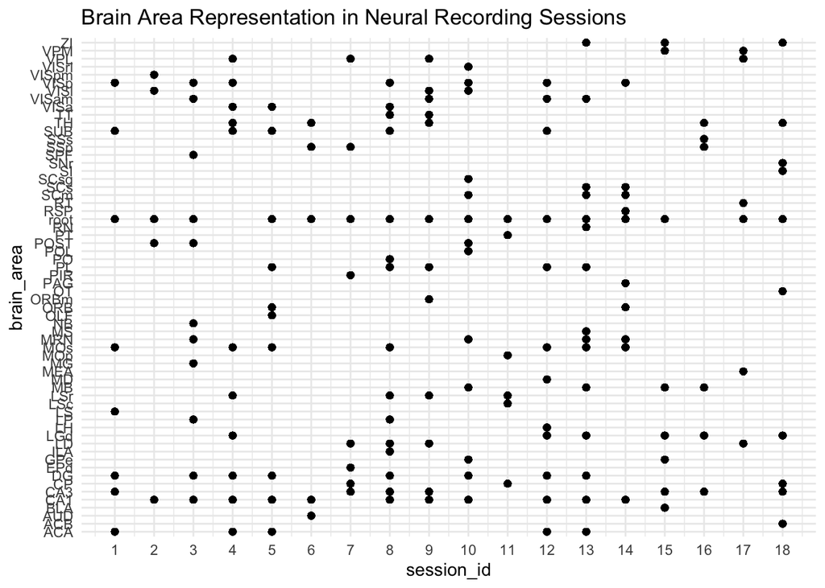

### Success Rate Estimation by Session

```
## # A tibble: 18 × 2
##    session_id success_rate
##    <fct>             <dbl>
##  1 1                 0.605
##  2 2                 0.633
##  3 3                 0.662
##  4 4                 0.667
##  5 5                 0.661
##  6 6                 0.741
##  7 7                 0.671
##  8 8                 0.644
##  9 9                 0.685
## 10 10                0.620
## 11 11                0.795
## 12 12                0.738
## 13 13                0.797
## 14 14                0.694
## 15 15                0.765
## 16 16                0.718
## 17 17                0.830
## 18 18                0.806
```

### Success Rate Estimation by Mouse Name

```
## # A tibble: 4 × 2
##   mouse_name success_rate
##   <chr>             <dbl>
## 1 Cori              0.639
## 2 Forssmann         0.687
## 3 Hench             0.684
## 4 Lederberg         0.761
```

Grouping the success rate by mouse name, the overall increasing trend is also reflected in this tibble. We can derive here that the further the session, the greater the success rate there may be.

To look at the difference of each trial, we may look at the distribution of the contrast difference

### Contrast Difference Distribution

```
## # A tibble: 5 × 4
##   contrast_diff     n  perc labels
##           <dbl> <int> <dbl> <chr>
## 1          0.25   718 0.141 14.13%
## 2          0.75   740 0.146 14.56%
## 3          1      892 0.176 17.56%
## 4          0.5   1045 0.206 20.57%
## 5          0     1686 0.332 33.18%
```

We can observe from the tibble that the highest distribution percentage is 33.18% when the contrast difference is at 0.00, followed by 20.57% at 0.50, and 17.56% at 1.00. In addition, the distribution is at about 14% when the contrast difference is at 0.25 and 0.75, illustrating a roughly similar distribution.

### Effect of Contrast Difference On Success Rate

```
## # A tibble: 5 × 2
##   contrast_diff success_rate
##           <dbl>        <dbl>
## 1          0           0.629
## 2          0.25        0.667
## 3          0.5         0.777
## 4          0.75        0.741
## 5          1           0.795
```

The success rate is highest when the contrast difference is at the largest value, which is 1, compared to the lowest contrast difference 0.00, which has the lowest success rate. We may conclude that greater success may be achieved if the contrast difference value is also greater.

### Disparities Among Mice on Contrast Differences and Success Rates

```
##            contrast_diff
## mouse_name           0       0.25        0.5       0.75          1
##   Cori      0.36256324 0.08768971 0.20236088 0.13153457 0.21585160
##   Forssmann 0.36555024 0.20095694 0.19425837 0.13301435 0.10622010
##   Hench     0.28773919 0.13465627 0.21190645 0.13182140 0.23387668
##   Lederberg 0.33612205 0.13090551 0.20816929 0.16584646 0.15895669
```

### Data Visualization

Visualizing success rate change over time (trial). The success rate is binned for each 25 trials.

### Success Rate Change Over Time For Individual Sessions

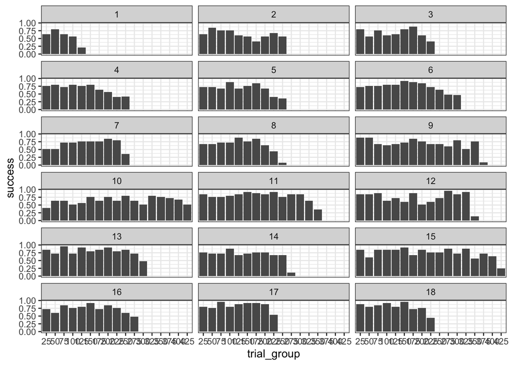

In the plot, we can see that there presents roughly about the same amount of variability across all sessions. However, some sessions have smaller amounts of data. This may be due to the unequal amount of trials per session. We can assume that sessions that have smaller data amounts have lesser number of trials compared to the other sessions.

### Success Rate Change Over Time For Individual Mice:

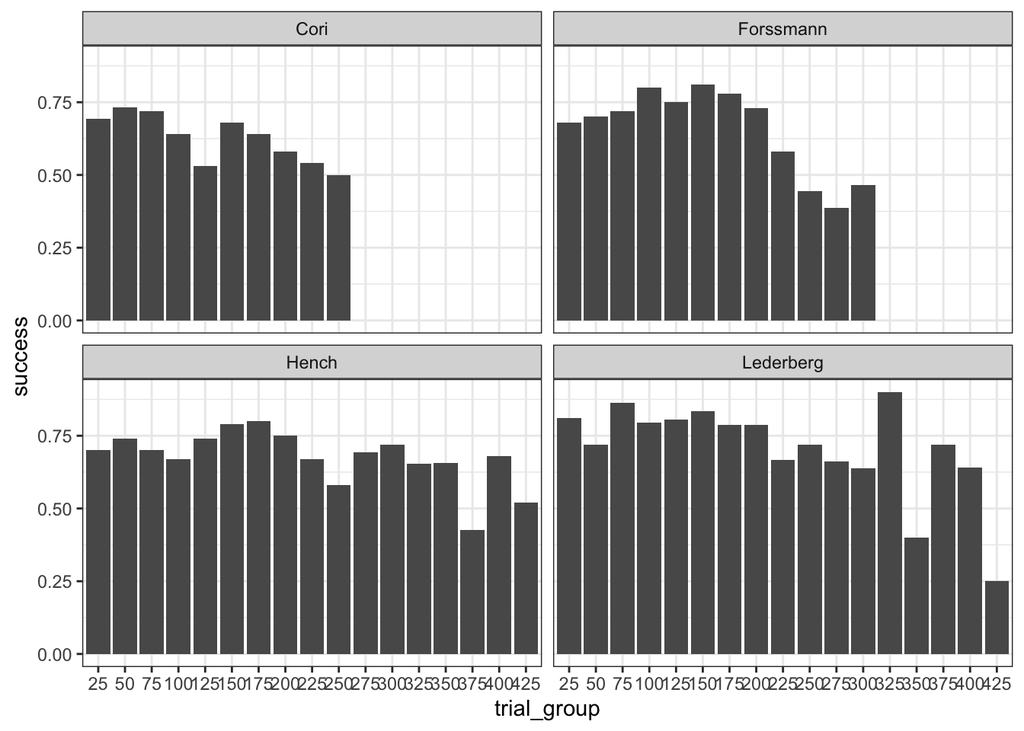

In the plot, we can see that there presents roughly about the same amount of variability across all mice, with some spike changes in mouse Lederberg. We can also see that the general trend of the success rate change is roughly equal, or slightly increases a little, then decreases over time. In addition, the unequal amount of trials per session is reflected in this plot. We can assume that mice Cori and Forssmann have lesser number of trials compared to mice Hench and Lederberg.

### Visualizing The Change of Overall Neuron Spike Rate Over Time

The `average_spike` is the number of spikes within each number bin divided total number of neurons for each trial.

### Change of Overall Neuron Spike Rate for Each Session

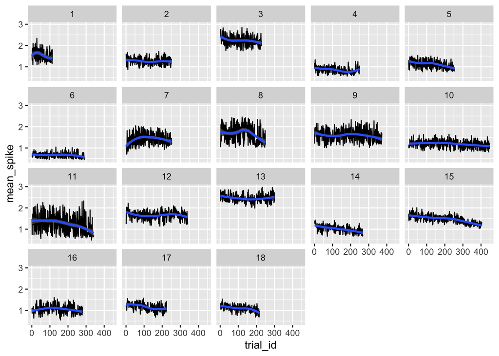

### Change of Overall Neuron Spike Rate for Each Mouse

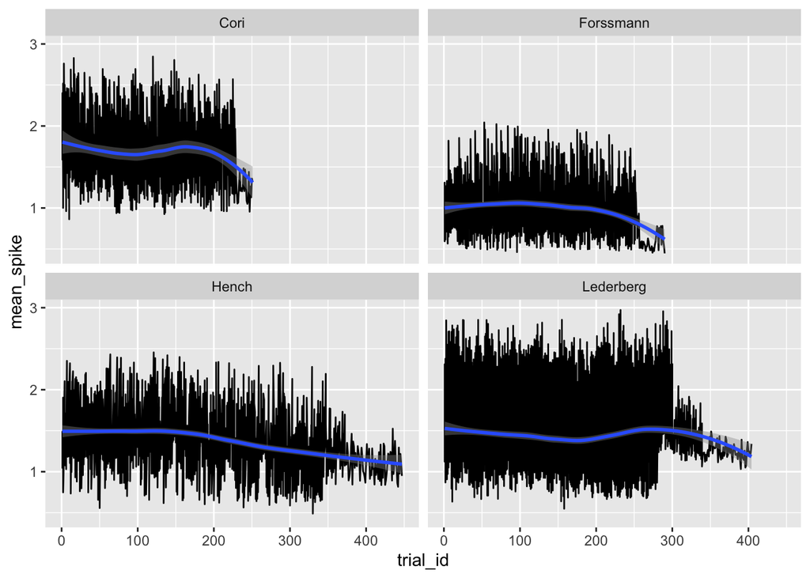

Mouse Lederberg has the most variability among all mice. However, there seems to be a trend for all mice where the change of overall neuron spike rate for each mouse drastically decreases in the end trials, along with its drastically shrinking variability.

## Dimension Reduction through PCA

We perform PCA and visualize the 2D results.

The dots are colored for different session.

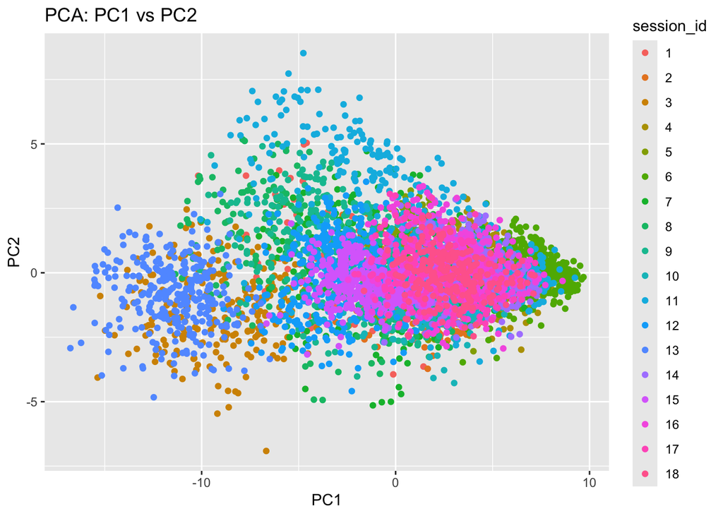

In this plot, we can see that there is a cluster of points on the right side of the plot, indicating a patterns of similar characteristics. In addition, we can see that the spread is greater on the x-axis, indicating that there is greater variability among these sessions.

The dots are colored for different mouse

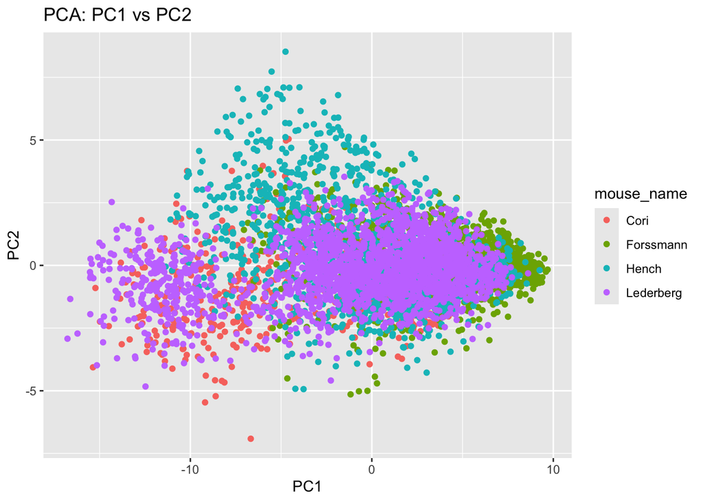